# cyclistic_bikeshare

Yaminee

23/02/2022

## Cyclistic Bikeshare Case Study Analysis

### Business Task

**To find the trends in usage pattern by user to increase profits for Cyclistic Bikes.**

Cyclistic, a bike-share company in Chicago believes that the future success of company depends on maximizing the number of annual memberships. Therefore, we will try to understand how casual riders and annual members use Cyclistic bikes differently. The insights will help us in pin pointing the aspects we can target to convert the casual riders into members leading to maximizing profits.

### Information about Data

In this analysis we will be using the data from Cyclistic’s historical trip data for last 1 year i.e. from Jan 2021 till Dec 2021. It is provided by Lyft Bikes and Scooters, LLC which operates the City of Chicago’s Divvy bicycle sharing service. Both of them are committed to supporting bicycling as an alternative transportation option. To check for license please [click here](https://ride.divvybikes.com/data-license-agreement). With this data we will be able to find the pattern in how the users used the services to pinpoint the trends and take necessary decisions accordingly. [Click here to download data](https://divvy-tripdata.s3.amazonaws.com/index.html)

### Data cleaning and manipulation process steps

- Downloaded data from site and stored it into working directory.
- Loaded the data into RStudio.
- Combined all the CSV files into one CSV file.
- Removed all incomplete trips.
- Removed trips where start time is greater than end time.
- Added new column for ride duration with column name trip_length and parsed it to hms format.
- Added new column to store day of week when ride started with name day_of_week.
- Added new column to store month the ride stared with column name month

### Summery of analysis

- Post preliminary analysis it is found that the casual riders use the bikes for longer duration than annual members while the number of rides are more for members as compaired to casual riders.
- On weekends the number of rides as well as ride duration is at higher side than during the week.
- The casual riders take more rides on weekends while for members it rises slightly during mid-week.
- The average ride duration is significantly higher for casual riders than members through-out the week.
- There is significant drop in number of rides in month of October, November, December, January, February and March. Post that they increase with July being the peak month.
- Entire year the average ride duration is greater for casual riders than the members.

### Supporting Visualization and Key Findings

#### 1) Count of rides and Average of ride duration for members and casual riders

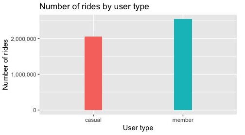

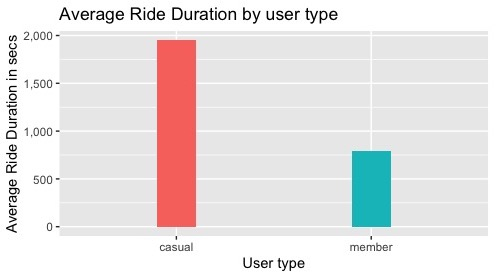

Number of rides for members are more than casual riders while the duration for them is lesser compared to members. This might me because they use the bikes daily for going to office and returning back only, which require lesser amount of time.

#### 2) Count of rides and Average of ride duration for days of the week

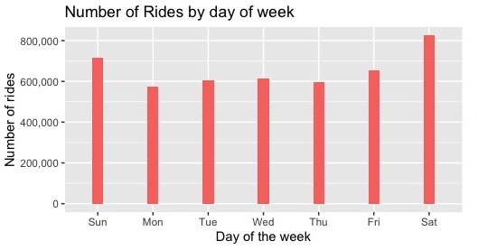

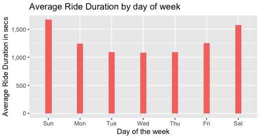

Increase in number of rides as well as longer ride duration during the weekend needs to be noted here.

#### 3) Count of rides and Average of ride duration for rider type by day of week

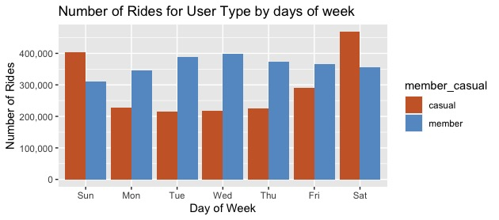

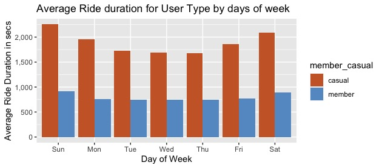

Increase in number of rides during weekends need to be noted along with longer ride duration for casual riders. It can help us drive our campaign.

#### 4) Count of rides and Average of ride duration for rider type by month

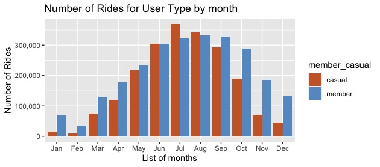

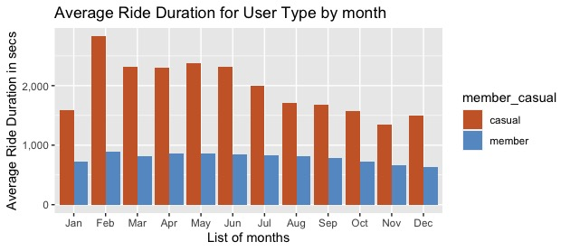

Drop in number of rides can be caused due to winter season. Increase in number of ridies during Jun, Jul, Aug and Sept can be used as an advantage to campaign something new. Longer ride duration for casual riders needs to be taken under consideration.

### Recomendations based on Analysis

- Create an annual weekend pass and campaign it.
- Make personalized email for Casual riders on how much hours they used the bike with money they paid. Later tell them how much they could have saved by taking annual membership.
- Run the campaign during the month of April till July as the number of rides increases significantly during this time period.